# BA_Assignment 2

```r
library(tidyverse)
getwd()
```

```
## [1] "/Users/thupiliabhinav/Desktop/BA/BA_Assignement 2"
```

```r
setwd("/Users/thupiliabhinav/Desktop/BA/BA_Assignement 2")
assign_1 <- read.csv("Online_Retail.csv")
```

#1.Breakdown of the number of transactions by countries. Transactions in percentages. Only 1% of transactions.

```r
ans1<- group_by(assign_1, Country)%>% count(Country)
ans1
```

| Country | n |
| --- | --- |
| Australia | 1259 |
| Austria | 401 |
| Bahrain | 19 |
| Belgium | 2069 |
| Brazil | 32 |
| Canada | 151 |
| Channel Islands | 758 |
| Cyprus | 622 |
| Czech Republic | 30 |
| Denmark | 389 |

[output cut: 28 more lines]

```r
ans12<- ans1$n*100/sum(ans1$n)
ans12
```

```
##  [1]  0.232326830  0.073997664  0.003506124  0.381798420  0.005905050
##  [6]  0.027864457  0.139875883  0.114779419  0.005535985  0.071783270
## [11]  1.512431054  0.011256502  0.128250315  1.579047405  1.752139197
## [16]  0.026941793  0.053145454  0.033584975  0.054806250  0.148179860
## [21]  0.066062752  0.008303977  0.006458649  0.023435669  0.437527334
## [26]  0.200402651  0.062925694  0.280305365  0.010702904  0.001845328
## [31]  0.042258017  0.467421652  0.085254166  0.369434721  0.012548232
## [36] 91.431956288  0.082301641  0.053699053
```

```r
ans123<-subset(ans12, ans12>1)
ans123
```

```
## [1]  1.512431  1.579047  1.752139 91.431956
```

#2.New variable “TransactionValue” and binding to the original dataframe.

```r
TransactionValue<- assign_1$Quantity*assign_1$UnitPrice
b_ans1<-cbind(assign_1,TransactionValue)
head(b_ans1)
```

|  | InvoiceNo | StockCode | Description | Quantity | InvoiceDate | UnitPrice | CustomerID | Country | TransactionValue |
| --- | --- | --- | --- | --- | --- | --- | --- | --- | --- |
| 1 | 536365 | 85123A | WHITE HANGING HEART T-LIGHT HOLDER | 6 | 12/1/2010 8:26 | 2.55 | 17850 | United Kingdom | 15.30 |
| 2 | 536365 | 71053 | WHITE METAL LANTERN | 6 | 12/1/2010 8:26 | 3.39 | 17850 | United Kingdom | 20.34 |
| 3 | 536365 | 84406B | CREAM CUPID HEARTS COAT HANGER | 8 | 12/1/2010 8:26 | 2.75 | 17850 | United Kingdom | 22.00 |
| 4 | 536365 | 84029G | KNITTED UNION FLAG HOT WATER BOTTLE | 6 | 12/1/2010 8:26 | 3.39 | 17850 | United Kingdom | 20.34 |
| 5 | 536365 | 84029E | RED WOOLLY HOTTIE WHITE HEART. | 6 | 12/1/2010 8:26 | 3.39 | 17850 | United Kingdom | 20.34 |
| 6 | 536365 | 22752 | SET 7 BABUSHKA NESTING BOXES | 2 | 12/1/2010 8:26 | 7.65 | 17850 | United Kingdom | 15.30 |

#3.Breakdown of transaction values by countries. Total transaction exceeding 130,000 British Pound.

```r
c_ans1<- summarise(group_by(b_ans1,Country), total.value= sum(TransactionValue))
c_ans12 <- filter(c_ans1, total.value>130000)
c_ans12
```

| Country | total.value |
| --- | --- |
| Australia | 137077.3 |
| EIRE | 263276.8 |
| France | 197403.9 |
| Germany | 221698.2 |
| Netherlands | 284661.5 |
| United Kingdom | 8187806.4 |

#4.Converting ‘InvoiceDate’ into a POSIXlt object.

```r
Temp=strptime(b_ans1$InvoiceDate,format='%m/%d/%Y %H:%M',tz='GMT')
head(Temp)
```

```
## [1] "2010-12-01 08:26:00 GMT" "2010-12-01 08:26:00 GMT"
## [3] "2010-12-01 08:26:00 GMT" "2010-12-01 08:26:00 GMT"
## [5] "2010-12-01 08:26:00 GMT" "2010-12-01 08:26:00 GMT"
```

#4.i. Day of the week and hour components dataframe with names as New_Invoice_Date, Invoice_Day_Week and New_Invoice_Hour:

```r
b_ans1$New_Invoice_Date <- as.Date(Temp)
```

$4.ii.Date objects

```r
b_ans1$New_Invoice_Date[20000]- b_ans1$New_Invoice_Date[10]
```

```
## Time difference of 8 days
```

#4.iii.Convert dates to days of the week

```r
b_ans1$Invoice_Day_Week= weekdays(b_ans1$New_Invoice_Date)
```

#4.iv.Convert into a normal numerical value

```r
b_ans1$New_Invoice_Hour = as.numeric(format(Temp, "%H"))
```

#4.v.Month as a separate numeric variable

```r
b_ans1$New_Invoice_Month = as.numeric(format(Temp, "%m"))
```

#4.a.Percentage of transactions (by numbers) by days of the week

```r
n_transactions<- group_by(b_ans1, Invoice_Day_Week) %>% summarise(value=n()) %>% mutate(percentage=value/nrow(b_ans1)*100)
n_transactions
```

| Invoice_Day_Week | value | percentage |
| --- | --- | --- |
| Friday | 82193 | 15.16731 |
| Monday | 95111 | 17.55110 |
| Sunday | 64375 | 11.87930 |
| Thursday | 103857 | 19.16503 |
| Tuesday | 101808 | 18.78692 |
| Wednesday | 94565 | 17.45035 |

#4.b.Percentage of transactions (by transaction volume) by days of the week

```r
n_transactions1 <- group_by(b_ans1, Invoice_Day_Week) %>% summarise(value= sum(TransactionValue)) %>% mutate(total= value/sum(value)*100)
n_transactions1
```

| Invoice_Day_Week | value | total |
| --- | --- | --- |
| Friday | 1540610.8 | 15.804787 |
| Monday | 1588609.4 | 16.297194 |
| Sunday | 805678.9 | 8.265282 |
| Thursday | 2112519.0 | 21.671867 |
| Tuesday | 1966182.8 | 20.170636 |
| Wednesday | 1734147.0 | 17.790232 |

#4.c.Percentage of transactions (by transaction volume) by month of the year

```r
n_transactions2 <- group_by(b_ans1, New_Invoice_Month) %>% summarise(value= sum(TransactionValue)) %>% mutate(total= value/sum(value)*100)
n_transactions2
```

| New_Invoice_Month | value | total |
| --- | --- | --- |
| 1 | 560000.3 | 5.744919 |
| 2 | 498062.7 | 5.109515 |
| 3 | 683267.1 | 7.009487 |
| 4 | 493207.1 | 5.059703 |
| 5 | 723333.5 | 7.420519 |
| 6 | 691123.1 | 7.090080 |
| 7 | 681300.1 | 6.989308 |
| 8 | 682680.5 | 7.003469 |
| 9 | 1019687.6 | 10.460751 |
| 10 | 1070704.7 | 10.984123 |

[output cut: 2 more lines]

#4.d.The date with the highest number of transactions from Australia?

```r
n_transactions3<- group_by(b_ans1, Country) %>% filter(Country=="Australia") %>% group_by(New_Invoice_Date) %>% summarise(value= n()) %>% arrange(desc(value))
n_transactions3
```

| New_Invoice_Date | value |
| --- | --- |
| 2011-06-15 | 139 |
| 2011-07-19 | 137 |
| 2011-08-18 | 97 |
| 2011-03-03 | 84 |
| 2011-10-05 | 82 |
| 2011-05-17 | 73 |
| 2011-02-15 | 69 |
| 2011-01-06 | 48 |
| 2011-07-14 | 35 |
| 2011-09-16 | 34 |

[output cut: 39 more lines]

#5

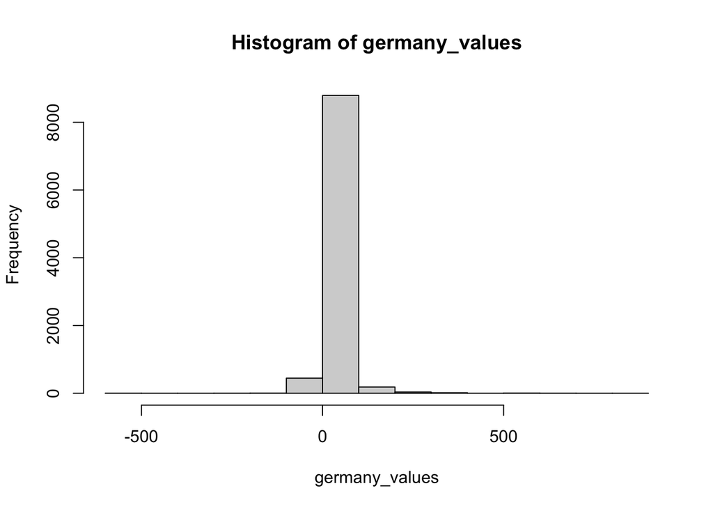

```r
germany_values<- subset(b_ans1$TransactionValue, b_ans1$Country == 'Germany')
hist(germany_values)
```

#6.Customer had the highest number of transactions. Most valuable customer.

```r
f_1 <-group_by(b_ans1,CustomerID) %>% select('CustomerID') %>%  na.omit(b_ans1) %>% summarise(value = n()) %>% arrange(desc(value))
f_1[which.max(f_1$value),]
```

| CustomerID | value |
| --- | --- |
| 17841 | 7983 |

```r
#Customer-ID 17841 has the highest number of transactions

f_ans<- summarise(group_by(b_ans1,CustomerID), Value= sum(TransactionValue)) %>% na.omit(b_ans1)
f_ans[which.max(f_ans$Value),]
```

| CustomerID | Value |
| --- | --- |
| 14646 | 279489 |

```r
#The most valuable customer is Customer-ID-14646.
```

#7. Percentage of missing values for each variable in the dataset

```r
missing_val<- colMeans(is.na(b_ans1)*100)
missing_val
```

```
##         InvoiceNo         StockCode       Description          Quantity
##           0.00000           0.00000           0.00000           0.00000
##       InvoiceDate         UnitPrice        CustomerID           Country
##           0.00000           0.00000          24.92669           0.00000
##  TransactionValue  New_Invoice_Date  Invoice_Day_Week  New_Invoice_Hour
##           0.00000           0.00000           0.00000           0.00000
## New_Invoice_Month
##           0.00000
```

#8.Number of transactions with missing CustomerID records by countries?

```r
missing_transaction <- b_ans1 %>% filter(is.na(CustomerID)) %>% group_by(Country)
summary(missing_transaction$Country)
```

```
##    Length     Class      Mode
##    135080 character character
```

#10.What is the return rate for the French customers?

```r
returns <- filter(b_ans1,Country=="France", Quantity<0) %>% count()
total_value<- filter(b_ans1, Country=="France") %>% count()

percentage_returns<- returns/total_value*100
percentage_returns
```

| n |
| --- |
| 1.741264 |

#11.Product that has generated the highest revenue for the retailer

```r
revenue<-b_ans1 %>% select(StockCode,TransactionValue) %>% group_by(StockCode) %>% summarise(sum= sum(TransactionValue)) %>% arrange(desc(sum))
revenue
```

| StockCode | sum |
| --- | --- |
| DOT | 206245.480 |
| 22423 | 164762.190 |
| 47566 | 98302.980 |
| 85123A | 97894.500 |
| 85099B | 92356.030 |
| 23084 | 66756.590 |
| POST | 66230.640 |
| 22086 | 63791.940 |
| 84879 | 58959.730 |
| 79321 | 53768.060 |

[output cut: 4060 more lines]

```r
#DOT has the highest revenue generated with sum of 206245.48
```

#12.unique customers are represented in the dataset

```r
unique_customer<- b_ans1%>% select(CustomerID) %>% unique() %>% count()
unique_customer
```

| n |
| --- |
| 4373 |